# Predicting Car Auction Prices

### By: Reese Karo

**Project Overview:**

This end-to-end project aims to predict car auction prices using various machine learning techniques, including XGBoost, and a Deep Neural Network. The data has been preprocessed and cleaned, and the models are evaluated based on their performance metrics. Both machine learning models use hyperparameter tuning to determine the best set of hyperparameters using different techniques, including: grid searching of pre-selected parameters, and Hyperband tuning.

```python
# import libraries
import pandas as pd
import numpy as np
import matplotlib.pyplot as plt
import seaborn as sns
import pickle
```

```python
path = '/Users/reese/Documents/School/UC Santa Barbra /PSTAT/131/Project'
```

## Data Preprocessing

### Importing and Cleaning Data

- **Data Source:** The data was initially cleaned using R and Tidyverse, and can be found here: https://github.com/reese-karo/Portfolio/blob/main/Car%20Auction%20Machine%20Learning%20Project/CarAuctionML.pdf. Further cleaning was performed in Python to remove outliers.
- **Outlier Removal:** Vehicles priced over $60,000 or under $1,000, and those with more than 200,000 miles on the odometer, were removed to improve model performance. Also by condensing to the top 8 vehicle colors were kept. We note that age is based off of 2015 results, where 2015 is the newest car at age 0.

```python
# Importing the data
cars_df = pd.read_csv(path + '/car_data_cleaned.csv')
# remove the unnamed column because it is an index column
cars_df = cars_df.drop(columns=['Unnamed: 0'])
# convert object types to categorical
cars_df = cars_df.apply(lambda x: x.astype('category') if x.dtype == 'object' else x)

print(cars_df.describe(), '\n')
print(cars_df.info(), '\n')
print(cars_df[:5], '\n')
```

[output not shown]

```python
# after further eda, we will need to remove outliers from the data
print('Count of cars that are priced more than 60000:', len(cars_df[cars_df['sellingprice'] > 60000]), 'out of', len(cars_df))
print('Removing outliers in price...')
cars_df = cars_df[(cars_df['sellingprice'] > 1000) & (cars_df['sellingprice'] < 60000)] # remove outliers in price
print('Removing outliers in odometer...')
cars_df = cars_df[cars_df['odometer'] < 200000]

print('Keeping the top 8 most common colors...')
cars_df = cars_df[cars_df['color'].isin(cars_df['color'].value_counts()[:8].index)]

cars_df.describe()
```

```
Count of cars that are priced more than 60000: 198 out of 78820
Removing outliers in price...
Removing outliers in odometer...
Keeping the top 8 most common colors...
```

|  | condition | odometer | sellingprice | age |
| --- | --- | --- | --- | --- |
| count | 71550.000000 | 71550.000000 | 71550.000000 | 71550.000000 |
| mean | 3.470734 | 61934.371349 | 13981.701621 | 4.457331 |
| std | 0.911604 | 43819.533838 | 8751.110917 | 3.411017 |
| min | 1.000000 | 1.000000 | 1050.000000 | 0.000000 |
| 25% | 2.800000 | 27729.750000 | 8000.000000 | 2.000000 |
| 50% | 3.600000 | 49139.500000 | 12500.000000 | 3.000000 |
| 75% | 4.200000 | 91009.500000 | 18400.000000 | 7.000000 |
| max | 5.000000 | 199979.000000 | 59800.000000 | 25.000000 |

### Exploratory Data Analysis (EDA)

- **Visualizations:** Pair plots and heatmaps were used to understand the relationships between variables.
- **Key Insights:** Age and odometer readings have the highest correlation, indicating that older cars with higher mileage tend to sell for less.

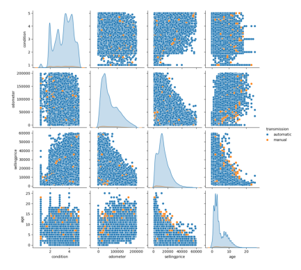

```python
# we will first use seaborn to show a few graphs and distributions of the data to get an understanding of the numerical data
numerics = ['int16', 'int32', 'int64', 'float16', 'float32', 'float64']
numeric_df = cars_df.select_dtypes(include=numerics)
numeric_df['transmission'] = cars_df['transmission'].astype('category')

'''
sns.pairplot(numeric_df, hue = 'transmission')
plt.savefig(path + '/pairplot.png')
plt.show()
'''

# load in the pairplot already created
pairplot = plt.imread(path + '/pairplot.png')
plt.imshow(pairplot)
plt.axis('off')
plt.show()
```

After removing outliers in the prices and the odometer, we have a good representation of some important predictors

Next we will get our correlation data to see what predictors are most influential on each other, having the highest and lowest correlations

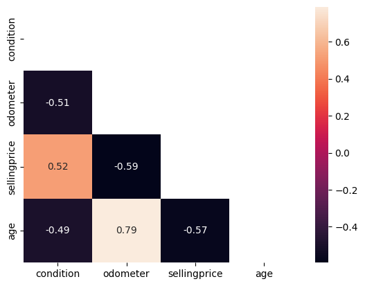

```python
# get correlation matrix
numeric_df = numeric_df.drop(columns=['transmission'])
corr_matrix = numeric_df.corr()

# mask
mask = np.triu(np.ones_like(corr_matrix, dtype=bool))

# plot the heatmap
sns.heatmap(corr_matrix, annot = True, mask = mask)
plt.show()
```

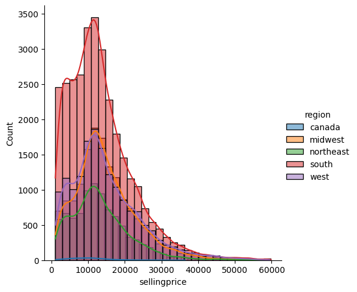

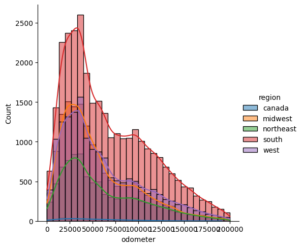

```python
sns.FacetGrid(cars_df, hue = 'region', height = 5).map(
    sns.histplot, 'sellingprice', bins = 30, kde = True).add_legend()
plt.show()

sns.FacetGrid(cars_df, hue = 'region', height = 5).map(
    sns.histplot, 'odometer', bins = 30, kde = True).add_legend()
plt.show()
```

### Pipeline

**Concept:**

- Split the data into training and testing first where the X train/test contains all but the prediction variable, and y train/test contains only the selling price data
- Next we collect a list of only numeric and categorical predictors so we can scale the numeric and change the catgeorical into 'One-Hot' or dummy variables
- Then we use a column transformer to combine the numerical and catgeorical columns into a preprocesser for the next step
- Then our official pipeline takes in the preprocesser, and removes any values with 0 variance.

This provides us with a transformed training and testing set to work with to train the models below.

```python
# start the preprocessing steps
from sklearn.compose import ColumnTransformer #
from sklearn.pipeline import Pipeline # handle the pipeline of preprocessing steps
from sklearn.preprocessing import OneHotEncoder, StandardScaler # scales the data
from sklearn.feature_selection import VarianceThreshold # removes zero variance predictors
from sklearn.model_selection import train_test_split # split the data into training and testing data

# split the data into training and testing data
X_train, X_test, y_train, y_test = train_test_split(cars_df.drop(columns=['sellingprice']),
                                                    cars_df['sellingprice'], test_size=0.2, random_state=12345)

##### create the pipeline #####

# create a list of numeric and categorical features
numeric_features = X_train.select_dtypes(include=['float64', 'int64']).columns.tolist()
categorical_features = X_train.select_dtypes(include=['category']).columns.tolist()

# create transformers for numeric and categorical data
numeric_transformer = Pipeline(steps=[
    ('scaler', StandardScaler())]) # normalize numeric features

categorical_transformer = Pipeline(steps=[
    ('onehot', OneHotEncoder(handle_unknown='ignore'))]) # handle novel categories with the ignore option

# combine transformers into a preprocessor
preprocessor = ColumnTransformer(
    transformers=[
        ('num', numeric_transformer, numeric_features),
        ('cat', categorical_transformer, categorical_features)
    ]
)

# create the main pipeline with variance thresholding for zero variance predictors
pipeline = Pipeline(steps=[
    ('preprocessor', preprocessor),
    ('variance', VarianceThreshold(threshold=0))
])

# fit and transform
X_train_processed = pipeline.fit_transform(X_train)
X_test_processed = pipeline.transform(X_test)
```

## Modeling

### XGBoost

```python
import xgboost as xgb
from sklearn.model_selection import KFold
from sklearn.model_selection import GridSearchCV
from sklearn.metrics import mean_squared_error
import numpy as np

# create a validation set
X_train_small, X_val, y_train_small, y_val = train_test_split(X_train_processed, y_train, test_size=0.1, random_state=12345)

# init the model
xgb_reg = xgb.XGBRegressor(objective='reg:squarederror', random_state=12345,
                           early_stopping_rounds=20) # including a validation set for early stopping

# set the parameter grid
param_grid_xgb = {
    'learning_rate': [0.01, 0.05], # learning rate
    'max_depth': [9, 12], # depth of each tree, higher is more complex
    'colsample_bytree': [0.5, 1] # controls the fraction of the observations to be randomly samples for each tree
}
# Fold the data into 10 folds
kfold = KFold(n_splits=10, shuffle=True, random_state=12345)
'''
# grid search for xgboost
tuning_xgb = GridSearchCV(estimator=xgb_reg,
                          param_grid=param_grid_xgb,
                          cv=kfold,
                          scoring='neg_mean_squared_error', # optimize for minimizing MSE
                          verbose=1) # show progress
# fit the tuning model
print('Tuning the model...')
tuning_xgb.fit(X_train_small, y_train_small, eval_set=[(X_val, y_val)])

# show the best parameters
best_xgb = tuning_xgb.best_params_
print('Best parameters:', best_xgb)

final_xgb = xgb.XGBRegressor(
    learning_rate=best_xgb['learning_rate'],  # higher learning rate after tuning
    max_depth=best_xgb['max_depth'],
    colsample_bytree=best_xgb['colsample_bytree'],
    early_stopping_rounds=20,
    random_state=12345
)

# Use early stopping while training to determine optimal number of trees
print('Fitting the final model...')
final_xgb.fit(X_train_processed, y_train,
              eval_set=[(X_val, y_val)],
              verbose=False)

# save the model
with open(path + '/final_xgb.pkl', 'wb') as f:
    pickle.dump(final_xgb, f)
'''
```

#### XGBoost Predictions

```python
with open(path + '/final_xgb.pkl', 'rb') as f:
    final_xgb = pickle.load(f)
# predict on the testing data
print('Using the final model to predict on the testing data...')
y_pred_xgb = final_xgb.predict(X_test_processed)

# evaluate the model
print('Evaluating the final model...')
mse_test_xgb = mean_squared_error(y_test, y_pred_xgb)
print(f'Mean Squared Error: {mse_test_xgb}')
```

```
Using the final model to predict on the testing data...
Evaluating the final model...
Mean Squared Error: 8817419.028055886
```

#### Visualizing XGB Performance

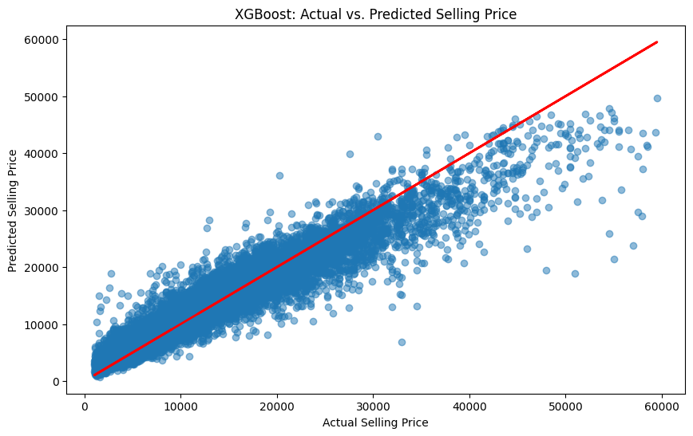

```python
# Plotting the Performance of XGBoost
plt.figure(figsize=(10, 6))
plt.scatter(y_test, y_pred_xgb, alpha=0.5)
plt.plot(y_test, y_test, color='red', linewidth=2)
plt.xlabel('Actual Selling Price')
plt.ylabel('Predicted Selling Price')
plt.title('XGBoost: Actual vs. Predicted Selling Price')
plt.show()
```

#### Results

- We see that the model performance follows the 1:1 ratio line of a perfect actual selling versus predicted selling price with predictions falling on both sides of the red line. This happens until the 30,000 actual selling price where we see the model starts to predict more expensive cars (truth) as less exepensive cars (pred). Thus some potential reasons could be the model didn't train enough on higher priced cars, since there are fewer cars that cost more than 30,000.

### Deep Neural Network (DNN)

#### Hyperparameter Tuning

Hyperband Tuning first explores a large number of configurations with a small number of training epochs, Then progressively increases the number of epochs for the most promising configurations, narrowing in on the best subset of hyperparameters  
We want to prioritize tuning learning rates, and network architectures first. Using dropout and early stopping and regularization, we can avoid overfitting.

The model builder below will generate us the best hyperparameters which we can train our final neural net model on the training dataset.

```python
import tensorflow as tf
import keras_tuner as kt
from tensorflow.keras.models import Sequential
from tensorflow.keras.layers import Dense, Dropout
from tensorflow.keras.callbacks import EarlyStopping, CSVLogger
```

```python
def model_builder(hp):
    '''
    This function builds neural nets to be passed into the tuner,
    finding the best hyperparameters for the training set.
    '''
    model = Sequential() # initialize the model
    model.add(Dense(units=hp.Int('units', min_value=32, max_value=512, step=32),
                    activation='relu',
                    kernel_regularizer=tf.keras.regularizers.l2(hp.Float('l2_reg', min_value=1e-4, max_value=1e-2, sampling='log')))) # dense layer with a variable number of units
    model.add(Dropout(rate=hp.Float('dropout', min_value=0.1, max_value=0.5, step=0.1))) # dropout layer with a variable dropout rate
    model.add(Dense(10, activation='relu')) # dense layer with 10 units
    model.add(Dense(1, activation='linear')) # output layer
    model.compile(optimizer=tf.keras.optimizers.Adam(hp.Choice('learning_rate', values=[1e-2, 1e-3, 1e-4])), # compile the model with the best learning rate out of the three options
                  loss='mean_squared_error',
                  metrics=['root_mean_squared_error'])
    return model

# add in callbacks
early_stopping = EarlyStopping(monitor='val_root_mean_squared_error',
                               patience=10,
                               restore_best_weights=True)
csv_logger = CSVLogger(path + '/training_logs.csv')

# initialize the tuner
tuner_nn = kt.Hyperband(model_builder,
                       objective='val_root_mean_squared_error', # objective is to minimize the validation root mean squared error
                       max_epochs=50, # maximum number of epochs to train the model
                       factor=3, # factor by which the number of epochs is increased
                       directory=path,
                       project_name='Car_price_NN_tuning') # directory to save the model

# search for the best hyperparameters
tuner_nn.search(X_train_processed, y_train, epochs = 50, validation_data =(X_val, y_val), callbacks=[early_stopping, csv_logger])

# get the best hyperparameters
best_hps = tuner_nn.get_best_hyperparameters(num_trials=1)[0]

# saving the best model with pickle
with open(path + '/best_hps.pkl', 'wb') as f:
    pickle.dump(best_hps, f)
```

```
Trial 90 Complete [00h 01m 58s]
val_root_mean_squared_error: 2903.47119140625

Best val_root_mean_squared_error So Far: 1893.8212890625
Total elapsed time: 00h 44m 07s
```

```python
from sklearn.metrics import mean_squared_error

# opening the best model with pickle
with open(path + '/best_hps.pkl', 'rb') as f:
    best_hps = pickle.load(f)

# build the model with the best hyperparameters
final_nn_model = tuner_nn.hypermodel.build(best_hps)
print(final_nn_model.summary()) # summary of the model

# different csv logger for the final training
train_csv_logger = CSVLogger(path + '/final_nn_training_logs.csv')

# Split the original training data into a new training and validation set
X_train_new, X_val, y_train_new, y_val = train_test_split(X_train_processed, y_train, test_size=0.1, random_state=12345)

# Retrain the model on the new training set
history = final_nn_model.fit(X_train_new, y_train_new,
                             validation_data=(X_val, y_val),
                             epochs=100,
                             callbacks=[early_stopping, train_csv_logger],
                             verbose=1)
```

```
Model: "sequential_1"
```

```
┏━━━━━━━━━━━━━━━━━━━━━━━━━━━━━━━━━┳━━━━━━━━━━━━━━━━━━━━━━━━┳━━━━━━━━━━━━━━━┓
┃ Layer (type)                    ┃ Output Shape           ┃       Param # ┃
┡━━━━━━━━━━━━━━━━━━━━━━━━━━━━━━━━━╇━━━━━━━━━━━━━━━━━━━━━━━━╇━━━━━━━━━━━━━━━┩
│ dense_3 (Dense)                 │ ?                      │   0 (unbuilt) │
├─────────────────────────────────┼────────────────────────┼───────────────┤
│ dropout_1 (Dropout)             │ ?                      │             0 │
├─────────────────────────────────┼────────────────────────┼───────────────┤
│ dense_4 (Dense)                 │ ?                      │   0 (unbuilt) │
├─────────────────────────────────┼────────────────────────┼───────────────┤
│ dense_5 (Dense)                 │ ?                      │   0 (unbuilt) │
└─────────────────────────────────┴────────────────────────┴───────────────┘
```

```
 Total params: 0 (0.00 B)
```

```
 Trainable params: 0 (0.00 B)
```

```
 Non-trainable params: 0 (0.00 B)
```

[output not shown]

```python
# Predict on the testing data
y_pred_nn = final_nn_model.predict(X_test_processed)

# Evaluate the model
mse_test_nn = mean_squared_error(y_test, y_pred_nn)
print(f'Mean Squared Error: {mse_test_nn:.2f}', '\n',
      f'Root Mean Squared Error: {np.sqrt(mse_test_nn):.2f}')
```

```
448/448 ━━━━━━━━━━━━━━━━━━━━ 0s 541us/step
Mean Squared Error: 5666732.52
 Root Mean Squared Error: 2380.49
```

### Visualizing the Training and Validation RMSE

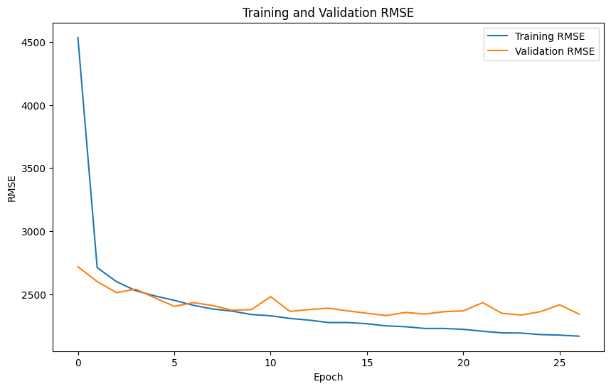

```python
# accessing the log file
log_file = pd.read_csv(path + '/final_nn_training_logs.csv')

# plotting the training and validation loss
plt.figure(figsize=(10, 6))
plt.plot(log_file['epoch'], log_file['root_mean_squared_error'], label='Training RMSE')
plt.plot(log_file['epoch'], log_file['val_root_mean_squared_error'], label='Validation RMSE')
plt.xlabel('Epoch')
plt.ylabel('RMSE')
plt.title('Training and Validation RMSE')
plt.legend()
plt.show()
```

The plot above shows us that our training RMSE drops significatntly within 3 epochs, while our validation RMSE stays relatively low and starts to increase around epoch 20. Having included the callback, `early_stopping`, the model knows when to stop training based off the validation RMSE.

#### Visualizing the Truth Vs. Predictions

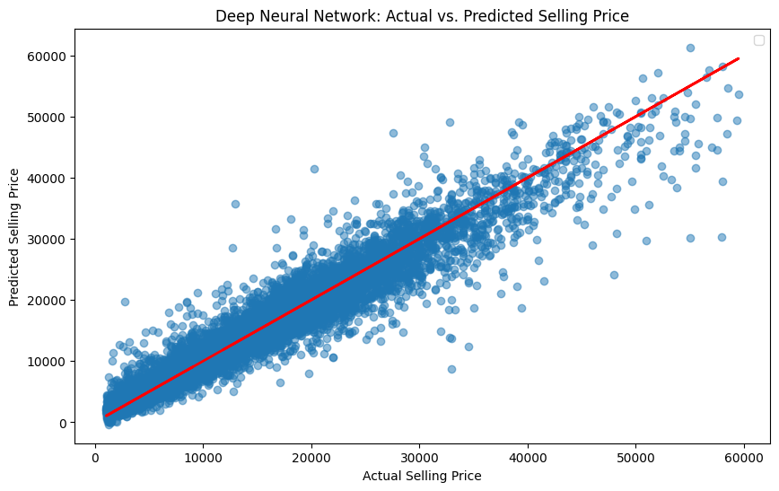

```python
plt.figure(figsize=(10, 6))
plt.scatter(y_test, y_pred_nn, alpha=0.5)
plt.plot(y_test, y_test, color='red', linewidth=2)
plt.xlabel('Actual Selling Price')
plt.ylabel('Predicted Selling Price')
plt.title('Deep Neural Network: Actual vs. Predicted Selling Price')
plt.legend()
plt.show()
```

#### Results

The plot above shows the fitting of the trained neural network predictions on the testing data. We see that the data fits much better to the true selling prices of the cars at auction. As we start to increase in price, the model ended up training better to the dataset than before, improving our results from the XGBoost Model from earlier.

## Conclusion

In this project, I successfully developed a XGBoost, and deep neural network model to predict the selling prices of cars at auction. Through careful data preprocessing and model training, we observed a significant reduction in training RMSE within the first few epochs, indicating that our model was learning effectively. The validation RMSE, however, began to increase after roughly 15-20 epochs, suggesting potential overfitting, which we addressed using the early stopping callback. Similar preventions to overfitting in the XGBoost model were taken, comparing the validation set and training performance.

The visualizations of actual versus predicted selling prices demonstrated that our models performed well. Particularly at higher price points, the Deep Neural Net outperformed the XGBoost model. This indicates that the neural network is capable of capturing complex patterns in the data, leading to more accurate predictions.

Overall, this project highlights the effectiveness of deep learning techniques in the domain of car auction price prediction and opens avenues for further exploration, such as hyperparameter tuning and the inclusion of additional features to enhance model performance.